# Bayesian modeling - `rstanarm`

## Model selection

We have trained 6 different models, in addition to the one that uses the correct model formulation. In a real application, how could we decide which model is the best? We have discussed multiple ways of evaluating the performance of regression models throughout the semester. This section reviews those methods from a full Bayesian perspective.

### Training set performance

Let’s first consider the behavior on the training set. We have been looking at the R-squared summaries throughout the model fitting process, but let’s visualize the R-squared posterior distributions now. The code chunk below uses `purrr::map2_dfr()` to extract the posterior R-squared samples and then displays the histogram for each model. As we saw with the posterior summaries displayed earlier, models 3, 5, and 6 have the highest posterior values, followed by model 4. The simplest model, the linear additive model is definitely worse, at least according to the training set.

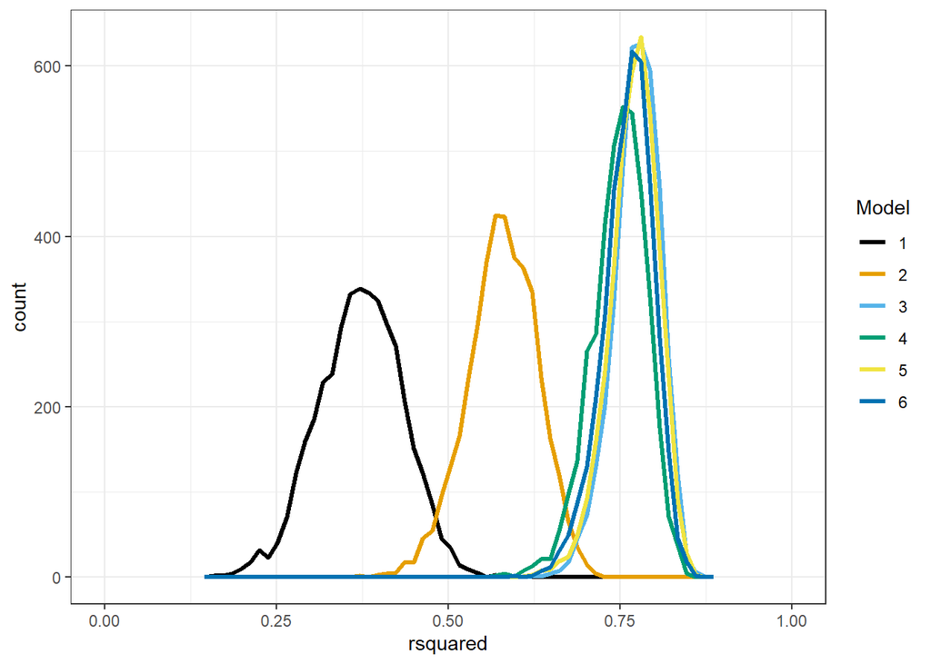

```r
purrr::map2_dfr(list(mod_1, mod_2, mod_3, mod_4, mod_5, mod_6),
                as.character(1:6),
                function(mod, mod_name){tibble::tibble(rsquared = bayes_R2(mod)) %>%
                    mutate(model_name = mod_name)}) %>%
  ggplot(mapping = aes(x = rsquared)) +
  geom_freqpoly(bins = 55,
                 mapping = aes(color = model_name),
                 size = 1.1) +
  coord_cartesian(xlim = c(0, 1)) +
  ggthemes::scale_color_colorblind("Model") +
  theme_bw()
```

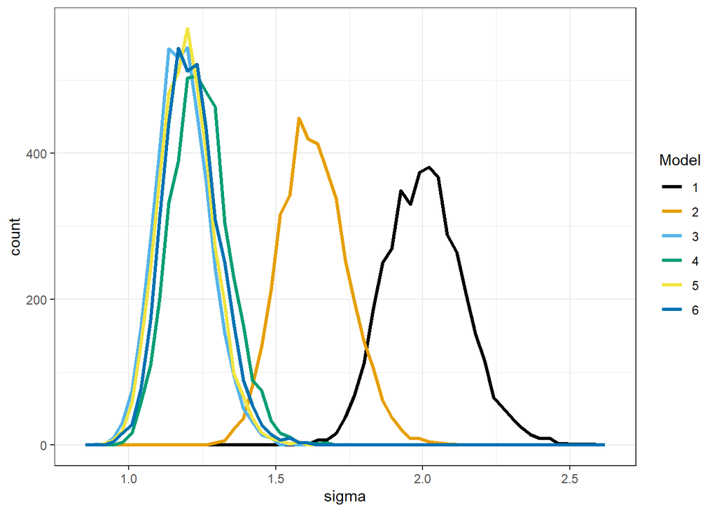

```r
purrr::map2_dfr(list(mod_1, mod_2, mod_3, mod_4, mod_5, mod_6),
                as.character(1:6),
                function(mod, mod_name){as.data.frame(mod) %>% tibble::as_tibble() %>%
                    select(sigma) %>%
                    mutate(model_name = mod_name)}) %>%
  ggplot(mapping = aes(x = sigma)) +
  geom_freqpoly(bins = 55,
                 mapping = aes(color = model_name),
                 size = 1.1) +
  ggthemes::scale_color_colorblind("Model") +
  theme_bw()
```

### Information criterion

We discussed how the Laplace Approximation provides an estimate to the log-Evidence (log-marginal likelihood). The log-Evidence penalizes the performance of complex models essentially based on the number of parameters, as shown by the BIC (which approximates the Laplace Approximation’s approximation). Unfortunately, we cannot use the log-Evidence based approach when we use MCMC sampling. However, we can use other information criterion that operate in the same way. The Widely Applicable Information Criterion (WAIC) is an approach that makes no assumptions about the posterior distribution. It calculates the performance of the model and penalizes that performance based on effective number of parameters. The penalty fully accounts for the joint posterior distribution of the parameters and the effect on the predictive behavior. We will not discuss how the WAIC is calculated in this report. For now, it is enough to think of it as an information criterion approach with fewer assumptions than the approach we used based on the Laplace Approximation.

The code chunk below calculates the WAIC for each of the 6 models and assigns the result as a new field in the model object. This will the facilitate the comparison method in the next step of the process. The warning messages displayed below recommend an approach that is described in the next section.

```r
mod_1$waic <- waic(mod_1)
```

```
## Warning:
## 1 (0.9%) p_waic estimates greater than 0.4. We recommend trying loo instead.
```

```r
mod_2$waic <- waic(mod_2)
```

```
## Warning:
## 9 (7.8%) p_waic estimates greater than 0.4. We recommend trying loo instead.
```

```r
mod_3$waic <- waic(mod_3)
mod_4$waic <- waic(mod_4)
mod_5$waic <- waic(mod_5)
mod_6$waic <- waic(mod_6)
```

The model objects are assigned as elements in the `stanreg_list()` function in the code chunk below. The `model_names` argument allows specified more informative names associated with each model.

```r
my_models <- stanreg_list(mod_1, mod_2, mod_3, mod_4, mod_5, mod_6,
                          model_names = c("Linear additive", "Pairwise Interactions",
                                          "Quadratic terms", "Interacting splines",
                                          "cubic with interactions",
                                          "cubic for all 5 inputs"))
```

```r
loo_compare(my_models, criterion = "waic")
```

```
## Model comparison based on WAIC:
##                         elpd_diff se_diff
## cubic with interactions   0.0       0.0
## Quadratic terms           0.0       3.4
## cubic for all 5 inputs   -2.2       1.7
## Interacting splines      -5.8       3.4
## Pairwise Interactions   -41.7       8.4
## Linear additive         -63.3      16.9
```

### LOO

We briefly discussed leave-one-out (LOO) cross-validation (CV) earlier in the semester during the “applied machine learning” portion of the course. We did not discuss it during the deep dive on the linear and generalized linear model derivations, when we focused on the likelihood and posterior distributions. With the Laplace Approximation as our inference engine, we focused on the information criterion based approaches for model selection.

However, Bayesian models can also benefit from cross-validation. Holding out data points helps identify which data points the posterior distribution is particular sensitive to, and thus serves as a form of sensitivity analysis. This is especially true if leave-one-out cross-validation is used. We can identify the specific data points that cause the largest change in the posterior. We did not perform this analysis this semester, but you could try it out if you would like. It just requires you to repeat the Laplace Approximation as many times as there are data points.

When we use MCMC sampling, a “brute force” approach to LOO is not advisable. The process would simply take too long, especially for large models and thousands of observations. Luckily, LOOCV can be approximated through Importance Sampling. Just how this works is beyond the scope of this course. Thus, we simply make use of the approach in this report without going into the details.

The approximate LOOCV is performed on the linear additive model below.

```r
loo_1 <- loo(mod_1)
```

```
## Warning: Found 1 observation(s) with a pareto_k > 0.7. We recommend calling 'loo' again with argument 'k_threshold = 0.7' in order to calculate the ELPD without the assumption that these observations are negligible. This will refit the model 1 times to compute the ELPDs for the problematic observ…
```

A warning message is displayed to the screen which represents that the posterior is quite sensitive to a few of the observations. We can visualize just which observations those are with the default plot method to the loo model object. As shown below, the 35th data point seems to influence the posterior quite a bit. Removing this data point yields different posterior distributions relative to the posterior associated with all data points.

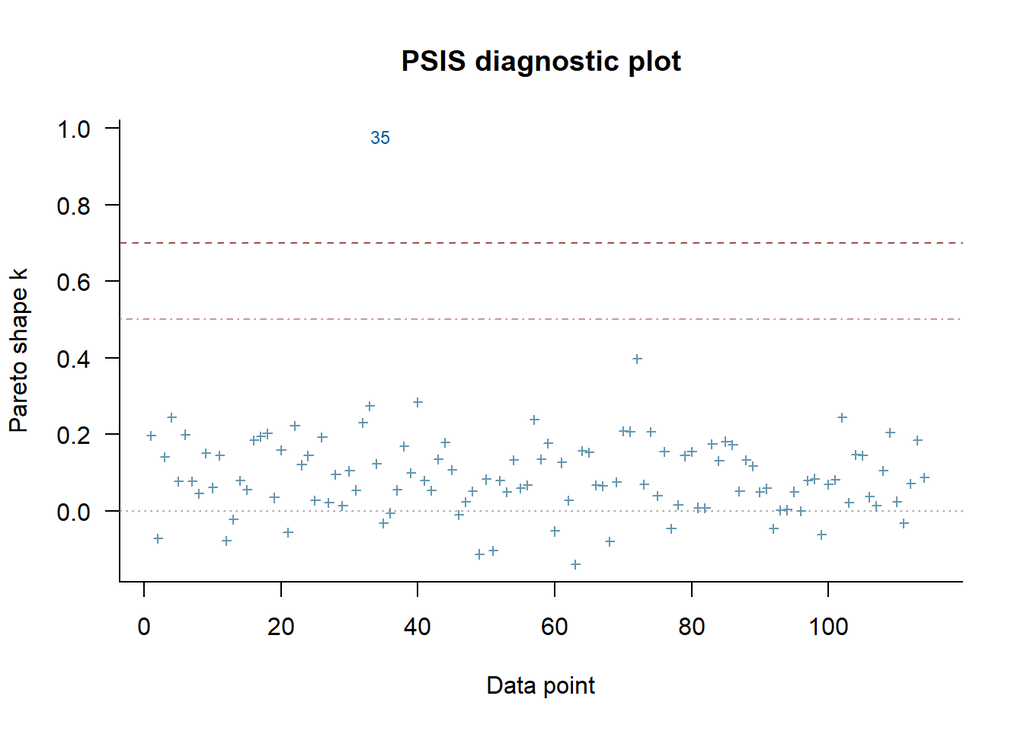

```r
plot(loo_1, label_points = TRUE)
```

Let’s follow the warning message and set the `k_threshold` value to 0.7 in the call to the `loo()` function. Doing so will refit the model (re-perform the sampling) with the 35th data point removed. Thus, the posterior distribution will be explicitly determined when the problematic point is removed, providing a more exact LOOCV estimate.

```r
loo_1_b <- loo(mod_1, k_threshold = 0.7)
```

```
## 1 problematic observation(s) found.
## Model will be refit 1 times.
```

```
##
## Fitting model 1 out of 1 (leaving out observation 35)
```

If we execute the `loo()` function on the second model, we also see that the warning message appears. However, there are 2 observations which are considered problematic.

```r
loo_2 <- loo(mod_2)
```

```
## Warning: Found 2 observation(s) with a pareto_k > 0.7. We recommend calling 'loo' again with argument 'k_threshold = 0.7' in order to calculate the ELPD without the assumption that these observations are negligible. This will refit the model 2 times to compute the ELPDs for the problematic observ…
```

The LOOCV diagnostic plot reveals that the posterior is also sensitive to data point 32, in addition to data point 35. Following the warning message will therefore require the fitting to be re-performed 2 times. Since the model is quite fast to fit, let’s go ahead and allow the MCMC sampling to be repeated by holding out each data point.

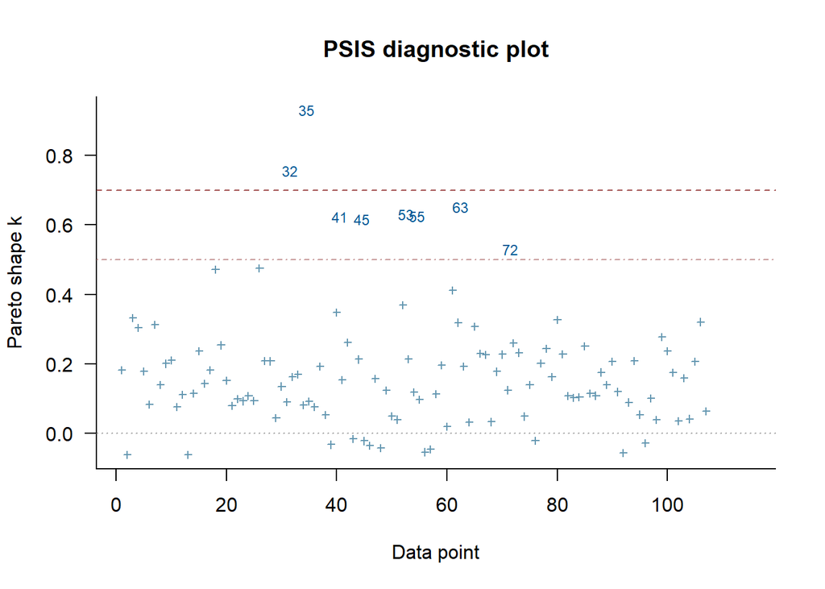

```r
plot(loo_2, label_points = TRUE)
```

```r
loo_2_b <- loo(mod_2, k_threshold = 0.7)
```

```
## 2 problematic observation(s) found.
## Model will be refit 2 times.
```

```
##
## Fitting model 1 out of 2 (leaving out observation 32)
```

```
##
## Fitting model 2 out of 2 (leaving out observation 35)
```

The LOOCV metric is calculated for the remaining 4 models below. Each model has different number of data points the posteriors are sensitive to, which requires the MCMC sampling to be re-performed. Thus, the LOOCV metric is more computationally expensive to evaluate compared to the WAIC metric which only considers the training set. However, the fourth model is not refit based on the sensitive data points. This was done to limit the computational requirements of rendering the report, because refitting the fourth model multiple times is rather time consuming.

```r
loo_3 <- loo(mod_3)
loo_3_b <- loo(mod_3, k_threshold = 0.7)
```

```
## 2 problematic observation(s) found.
## Model will be refit 2 times.
```

```
##
## Fitting model 1 out of 2 (leaving out observation 35)
```

```
##
## Fitting model 2 out of 2 (leaving out observation 53)
```

Again, the MCMC sampling is not re-performed for the fourth model, simply to limit the computational requirements of rendering this report. A complete analysis would require refitting. If we would, the fitting can be performed in parallel to save time.

```r
loo_4 <- loo(mod_4)
loo_5 <- loo(mod_5)
loo_5_b <- loo(mod_5, k_threshold = 0.7)
```

```
## 5 problematic observation(s) found.
## Model will be refit 5 times.
```

```
##
## Fitting model 1 out of 5 (leaving out observation 4)
```

```
##
## Fitting model 2 out of 5 (leaving out observation 32)
```

```
##
## Fitting model 3 out of 5 (leaving out observation 33)
```

```
##
## Fitting model 4 out of 5 (leaving out observation 35)
```

```
##
## Fitting model 5 out of 5 (leaving out observation 63)
```

```r
loo_6 <- loo(mod_6)
loo_6_b <- loo(mod_6, k_threshold = 0.7)
```

```
## 6 problematic observation(s) found.
## Model will be refit 6 times.
```

```
##
## Fitting model 1 out of 6 (leaving out observation 4)
```

```
##
## Fitting model 2 out of 6 (leaving out observation 32)
```

```
##
## Fitting model 3 out of 6 (leaving out observation 33)
```

```
##
## Fitting model 4 out of 6 (leaving out observation 35)
```

```
##
## Fitting model 5 out of 6 (leaving out observation 53)
```

```
##
## Fitting model 6 out of 6 (leaving out observation 63)
```

We can now compare the 6 models based on the LOOCV metric. Let’s first compare the models using the original approximate LOOCV metric which can be impacted by the sensitive observations. The `loo_compare()` function is used again, but we pass in each of the loo objects. The results are displayed in similar fashion as to the WAIC comparisons, with the best performing model listed first. The `elpd_diff` tells us the difference in performance between a model from the best performing model. The `se_diff` let’s us know if that difference is within the standard error or not. If the difference is within the standard error then the model it is difficult to distinguish the differences between the two models.

```r
loo_compare(loo_1, loo_2, loo_3, loo_4, loo_5, loo_6)
```

```
##       elpd_diff se_diff
## mod_3   0.0       0.0
## mod_5  -0.9       3.3
## mod_6  -3.0       3.2
## mod_4  -7.8       3.8
## mod_2 -41.5       8.0
## mod_1 -61.8      15.5
```

Based on the results displayed above, `mod_3` and `mod_5` have essentially the same performance. This is consistent with the WAIC results we saw earlier. However, it is difficult to distinguish if `mod_6` is worse than `mod_3` since the `se_diff` value is greater than the `elpd_diff` value for the row associated with `mod_6` in the output above. The approximate LOOCV metric, which does not require refitting the model, is sensitive to various observations. Thus, let’s now rank the models based on the more accurate LOOCV metrics which did refit the models (except `mod_4`):

```r
loo_compare(loo_1_b, loo_2_b, loo_3_b, loo_4, loo_5_b, loo_6_b)
```

```
##       elpd_diff se_diff
## mod_3   0.0       0.0
## mod_5  -5.2       4.6
## mod_6  -7.4       4.2
## mod_4  -8.9       3.9
## mod_2 -42.7       8.6
## mod_1 -62.8      16.3
```

As shown above, using the more accurate calculations reveal that `mod_3` is considered to be the best. None of the other models have `elpd_diff` values within their corresponding `se_diff`. In fact, the more complex `mod_6` has an `elpd_diff` nearly twice it’s standard error, representing we can be quite confident that `mod_3` is better than `mod_6`.

### Model weights

The LOOCV metric, as with the information criterion based approaches, have comparisons that are not in the units of the response. Thus, the results are a little tricky to interpret outside of the definite ranking that can be performed. In lecture, we discussed how we can estimate a “model weight” which represents the probability of one model relative to the others considered. The `loo_model_weights()` function will calculate the model weights for us, based on the LOOCV metric. It has the same interpretation as the posterior model weight quantity we discussed in class. The weights are based on the LOOCV metric rather than the log-Evidence calculation from the Laplace Approximation.

Let’s now calculate the model weights for our 6 models. We can pass in the model objects directly to `loo_model_weights()` and the function will calculate the LOOCV metrics. It will even refit the models if there are sensitive observations, if we would like. Thus, the `loo_model_weights()` function can be rather computationally expensive if we are not careful. I prefer to pass in the already calculated LOOCV metric results as a list, to have greater control over the execution. There are several methods for calculating the model weights. We will use the default method known as stacking.

```r
loo_model_weights(list(`1` = loo_1_b, `2` = loo_2_b,
                       `3` = loo_3_b, `4` = loo_4,
                       `5` = loo_5_b, `6` = loo_6_b))
```

```
## Method: stacking
## ------
##   weight
## 1 0.000
## 2 0.000
## 3 0.752
## 4 0.000
## 5 0.248
## 6 0.000
```

As shown in the output displayed above `mod_3` has a weight of about 75%, followed by `mod_5` with a weight of about 25%. The third model includes the quadratic terms and interactions, and is a subset of `mod_5` which includes the cubic terms. The other models are therefore either too simple, and underfit the data, or are too complex and represent overfitting the data.

### Relative behavior

It is important to remember that the model selection rankings and especially the model weights are based on the specific candidate set of models being considered. The best model, `mod_3`, contains the features associated with the true model formulation. However, it also includes features associated with the “inactive inputs” `x4` and `x5`. This was done to represent a realistic application where we do not know which variables are not important ahead of time.

Let’s see what happens to the model selection rankings if we would consider the true formulation, `mod_a`. The LOOCV metric is calculated for `mod_a` below.

```r
loo_a <- loo(mod_a)
```

The approximate LOOCV metric was sensitive to a single observation. As shown below, observation 35 is the culprit again.

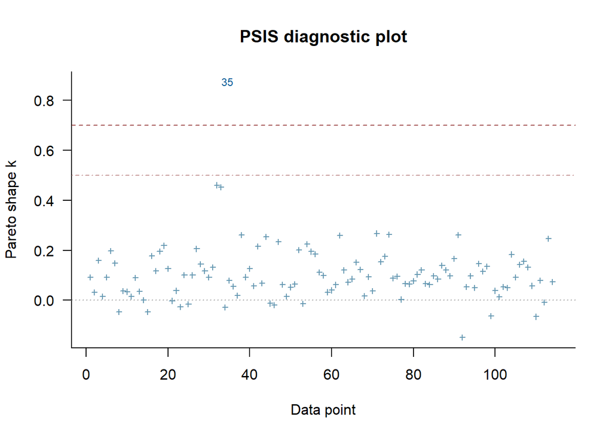

```r
plot(loo_a, label_points = TRUE)
```

Let’s refit the model by removing observation 35, and thus calculating the more exact leave-one-out metric.

```r
loo_a_b <- loo(mod_a, k_threshold = 0.7)
```

```
## 1 problematic observation(s) found.
## Model will be refit 1 times.
```

```
##
## Fitting model 1 out of 1 (leaving out observation 35)
```

```r
loo_compare(loo_1_b, loo_2_b, loo_3_b, loo_4, loo_5_b, loo_6_b, loo_a_b)
```

```
##       elpd_diff se_diff
## mod_a   0.0       0.0
## mod_3  -8.2       2.8
## mod_5 -13.5       4.1
## mod_6 -15.6       4.0
## mod_4 -17.1       4.1
## mod_2 -50.9       9.1
## mod_1 -71.0      16.1
```

Including the correct formulation completely changes the model weights. The correct formulation, `mod_a`, has a weight of over 98%. All other models that we tried are considered to be essentially meaningless, relative to `mod_a`. Interestingly, the simplest model with linear additive terms has a small weight of 0.016 or 1.6%. This may represent that the more complex models which have features similar to the correct formulation do not “add” value relative to the behavior of the correct formulation.

```r
loo_model_weights(list(`1` = loo_1_b, `2` = loo_2_b,
                       `3` = loo_3_b, `4` = loo_4,
                       `5` = loo_5_b, `6` = loo_6_b,
                       a = loo_a_b))
```

```
## Method: stacking
## ------
##   weight
## 1 0.016
## 2 0.000
## 3 0.000
## 4 0.000
## 5 0.000
## 6 0.000
## a 0.984
```